# Exploring One Variable with R

### Load the Pseudo-Facebook User Data

```r
pf <- read.csv('pseudo_facebook.tsv',sep = '\t')
names(pf)
```

```
##  [1] "userid"                "age"
##  [3] "dob_day"               "dob_year"
##  [5] "dob_month"             "gender"
##  [7] "tenure"                "friend_count"
##  [9] "friendships_initiated" "likes"
## [11] "likes_received"        "mobile_likes"
## [13] "mobile_likes_received" "www_likes"
## [15] "www_likes_received"
```

### Histogram of Users’ Birthdays

```r
library(ggplot2)

names(pf)
```

```
##  [1] "userid"                "age"
##  [3] "dob_day"               "dob_year"
##  [5] "dob_month"             "gender"
##  [7] "tenure"                "friend_count"
##  [9] "friendships_initiated" "likes"
## [11] "likes_received"        "mobile_likes"
## [13] "mobile_likes_received" "www_likes"
## [15] "www_likes_received"
```

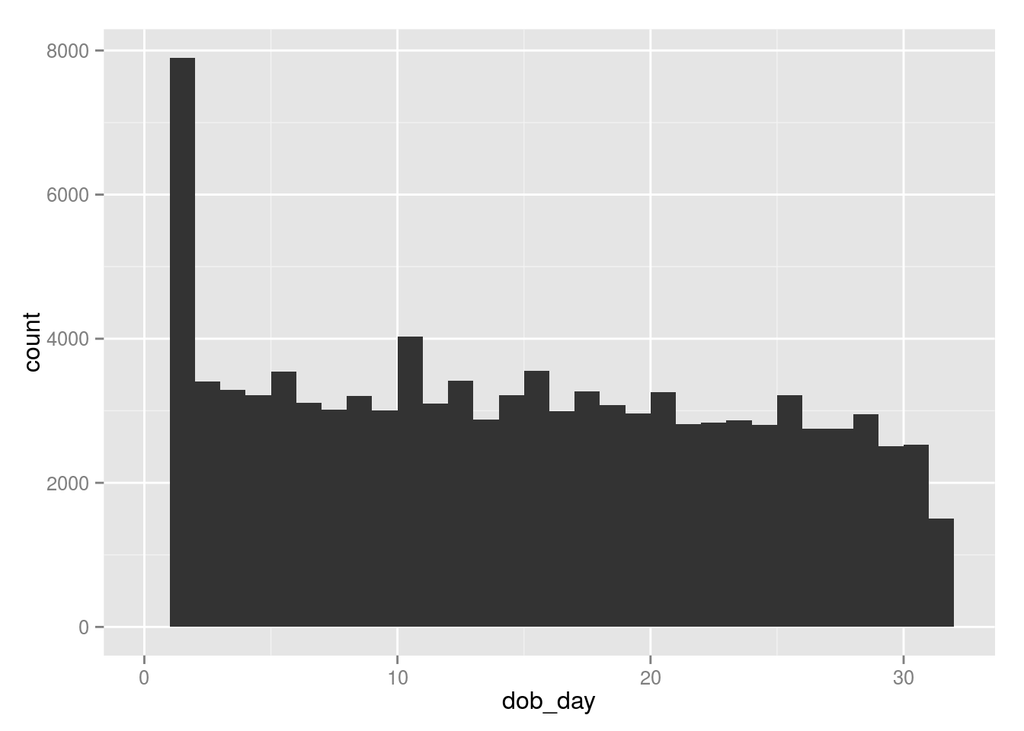

```r
qplot(x = dob_day, data = pf)
```

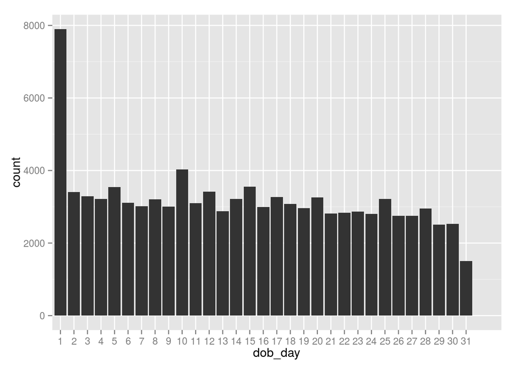

```r
qplot(x = dob_day, data = pf) +
  scale_x_discrete(breaks=1:31)
```

### Faceting

Notes: This takes a ~ and a variable. Here we are plotting one histogram for each month in the same plot.

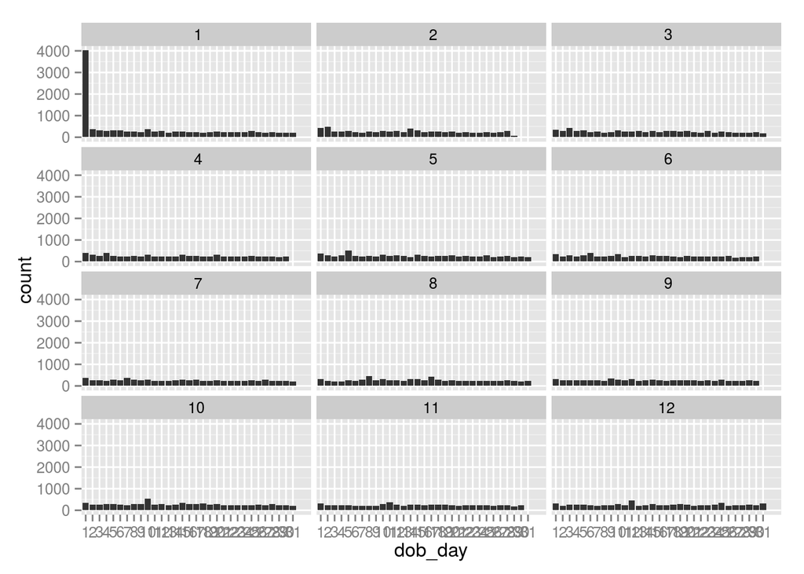

```r
qplot(x = dob_day, data = pf) +
  scale_x_discrete(breaks = 1:31) +
  facet_wrap(~dob_month, ncol = 3)
```

Notes: This is similar to facet_grid(). This takes as a parameter a formula in the format: (vertical variable ~ horizontal variable).

See the facet documentation.

#### Create a histogram of friend counts

Basic Plot

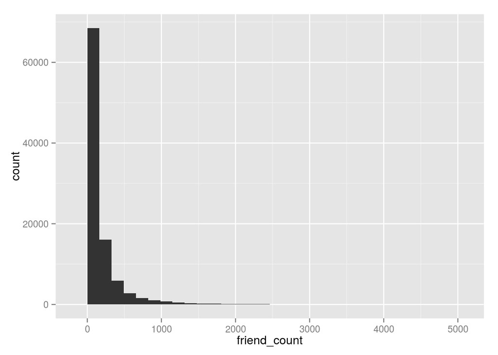

```r
qplot(x = friend_count, data = pf)
```

This limits the x axis to 1000 so we can see more detail in the bulk of the data. 2 different methods for the same plot.

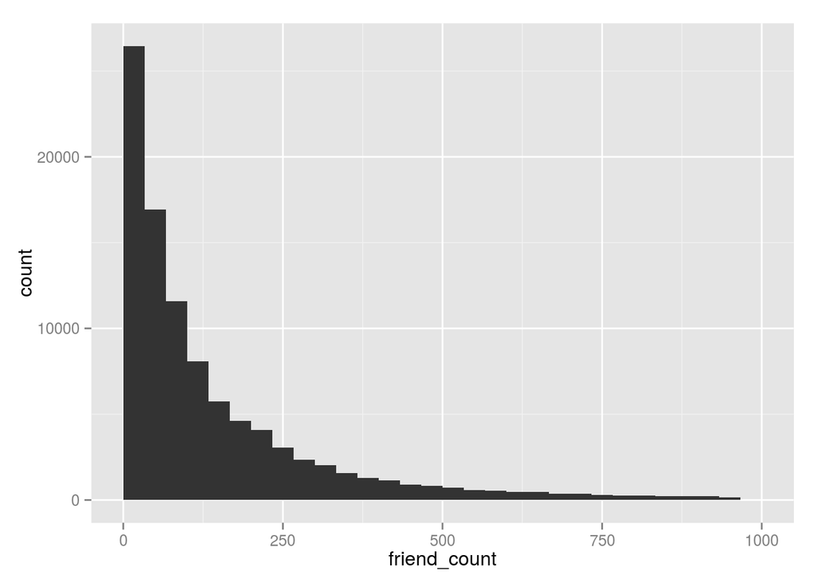

```r
qplot(x = friend_count, data = pf, xlim = c(0, 1000))
```

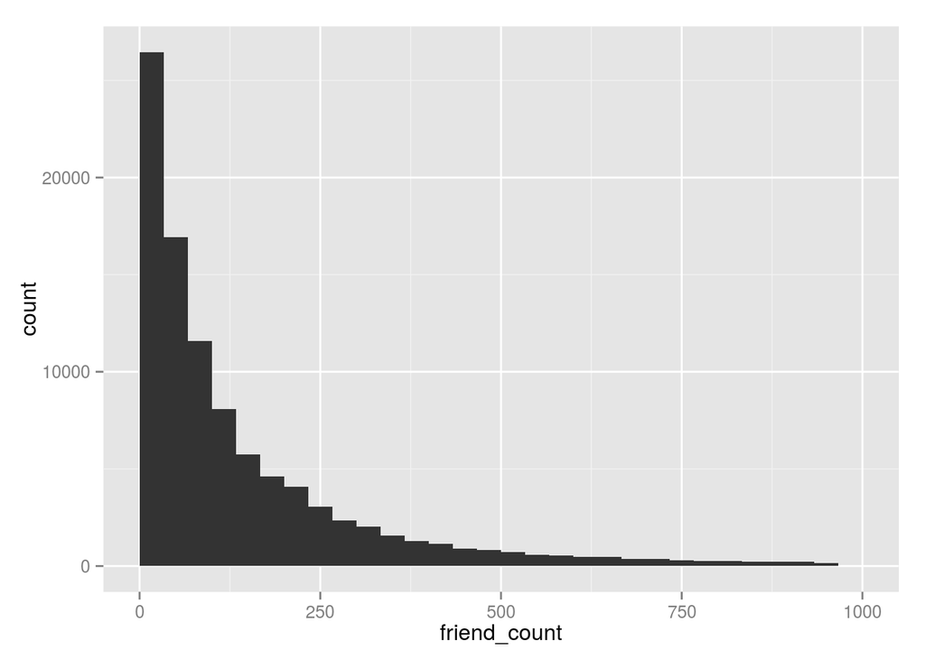

```r
qplot(x = friend_count, data = pf) +
  scale_x_continuous(limits = c(0, 1000))
```

### Faceting Friend Count

Create a histogram by gender breaking up the x axis by 50 units

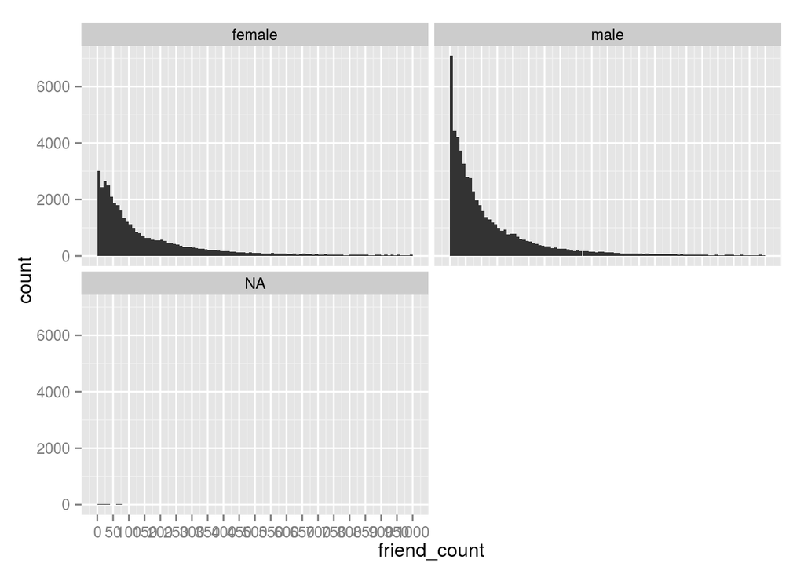

```r
qplot(x = friend_count, data = pf, binwidth = 10) +
  scale_x_continuous(limits = c(0, 1000),
                     breaks = seq(0, 1000, 50)) +
  facet_wrap(~gender, ncol=2)
```

#### What? Why are there 3 histograms? #### Let’s subset the data 2 different ways

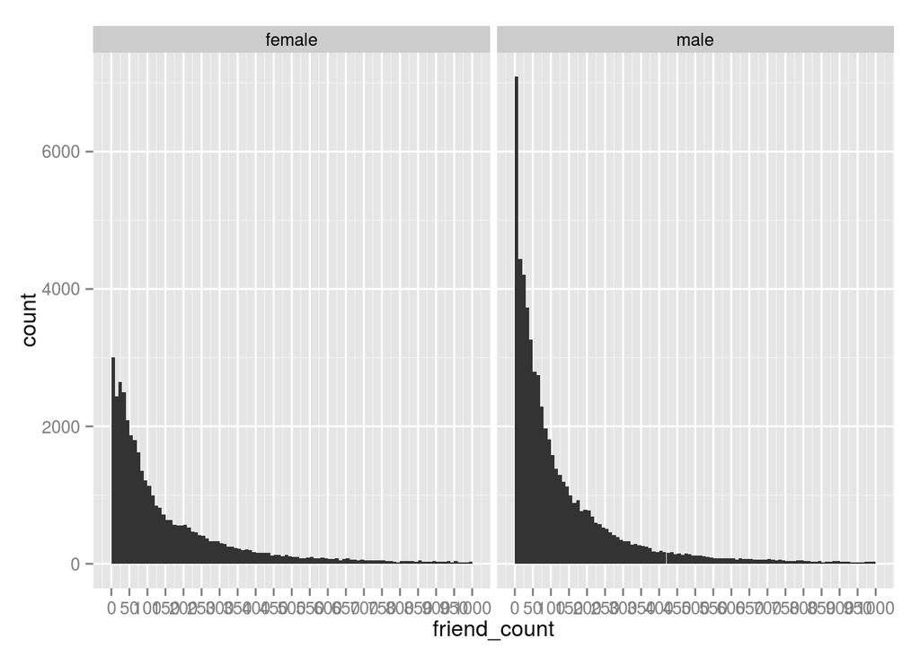

```r
# This removes all data with gender as NA
qplot(x = friend_count, data = subset(pf, !is.na(gender)), binwidth = 10) +
  scale_x_continuous(limits = c(0, 1000),
                     breaks = seq(0, 1000, 50)) +
  facet_wrap(~gender, ncol=2)
```

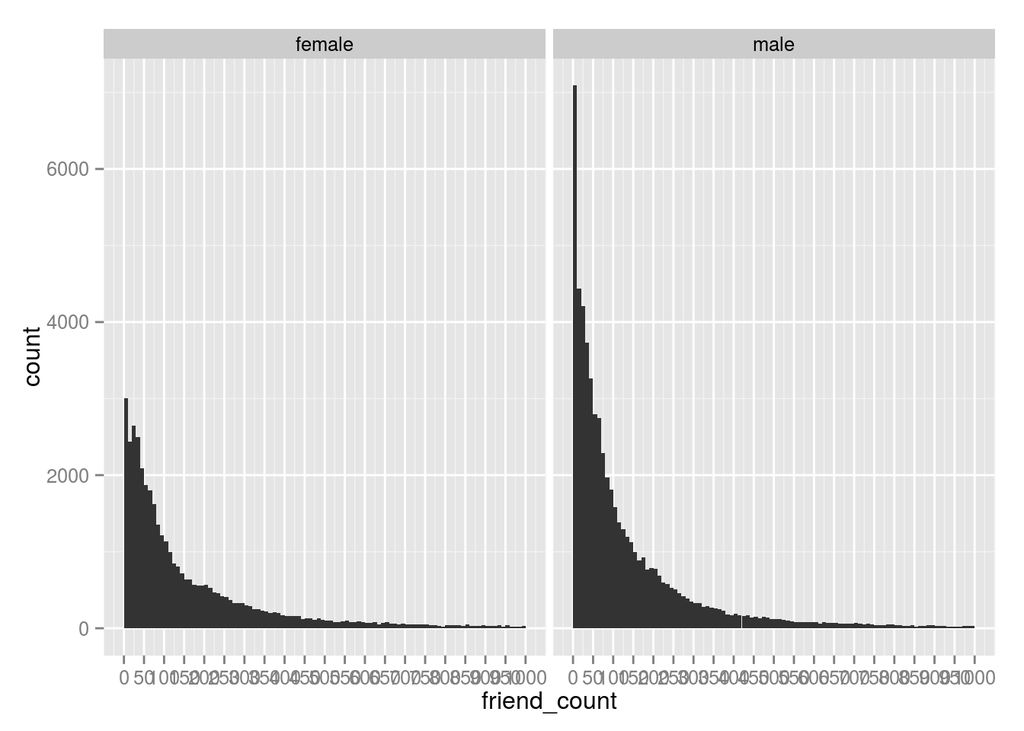

```r
# This removes all NA values for any field
qplot(x = friend_count, data = na.omit(pf), binwidth = 10) +
  scale_x_continuous(limits = c(0, 1000),
                     breaks = seq(0, 1000, 50)) +
  facet_wrap(~gender, ncol=2)
```

#### Ok, that is better.

### Statistics ‘by’ Gender

```r
table(pf$gender)
```

```
##
## female   male
##  40254  58574
```

```r
# the by function takes a variable, a categoricical variable and a function as parameters
by(pf$friend_count, pf$gender, summary)
```

```
## pf$gender: female
##    Min. 1st Qu.  Median    Mean 3rd Qu.    Max.
##       0      37      96     242     244    4923
## --------------------------------------------------------
## pf$gender: male
##    Min. 1st Qu.  Median    Mean 3rd Qu.    Max.
##       0      27      74     165     182    4917
```

On average women have more friends. In a long tailed distribution like this one, the median is a better measure of central tendency than the mean. ***

### Tenure

Notes:

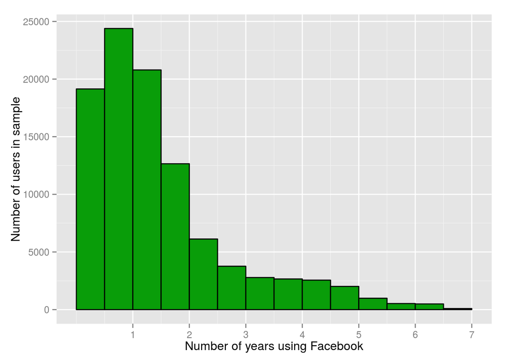

```r
# Using qplot
qplot(x=tenure/365, data=pf,
      xlab='Number of years using Facebook',
      ylab = 'Number of users in sample',
      binwidth=0.5,
      color=I('black'), fill=I('#099D09')) +
    scale_x_continuous(breaks=seq(1,7,1), limits=c(0,7))
```

#### Create a histogram of tenure by year?

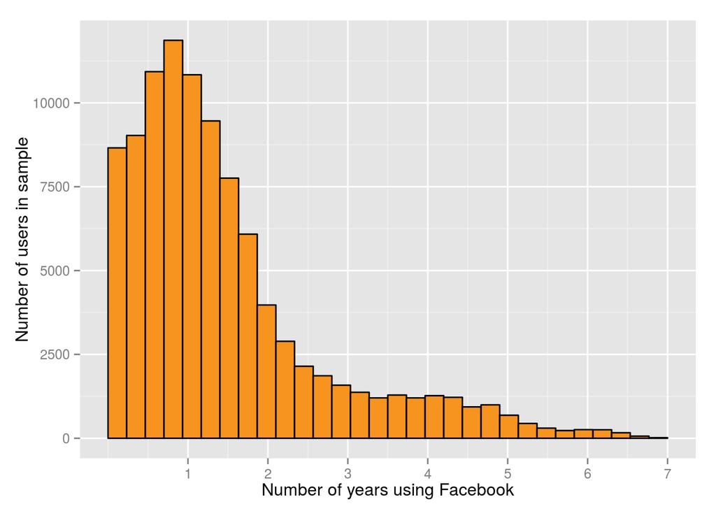

```r
# Using ggplot
ggplot(aes(x = tenure / 365), data = pf) +
  geom_histogram(color = 'black', fill = '#F79420') +
  scale_x_continuous(breaks = seq(1, 7, 1), limits = c(0, 7)) +
  xlab('Number of years using Facebook') +
  ylab('Number of users in sample')
```

### User Ages

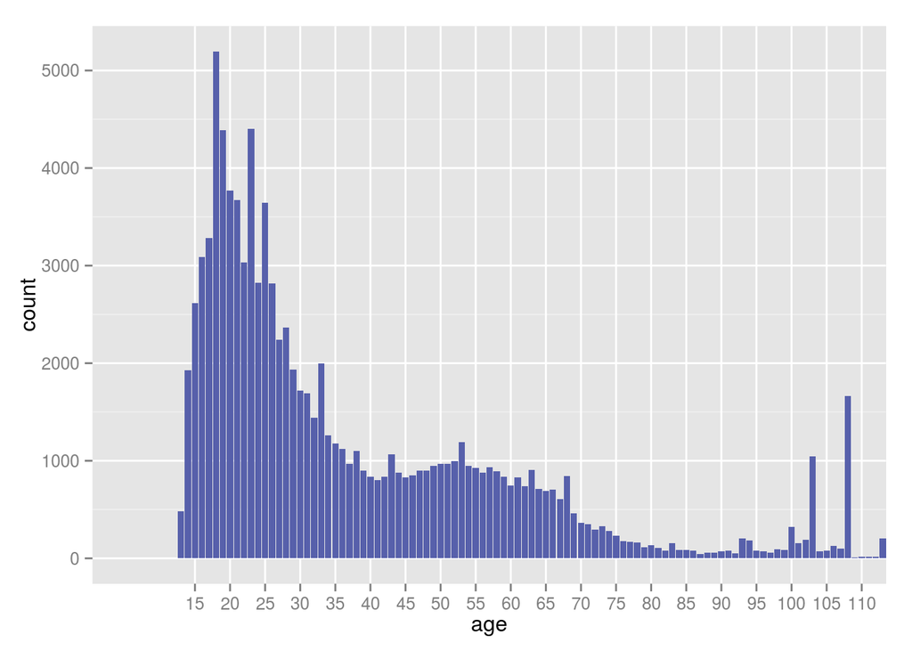

```r
qplot(x=age, data=pf, binwidth = 1,
      fill=I('#5760AB')) +
  scale_x_discrete(breaks = seq(0,113,5))
```

***

### Transforming Data

Plot friend counts

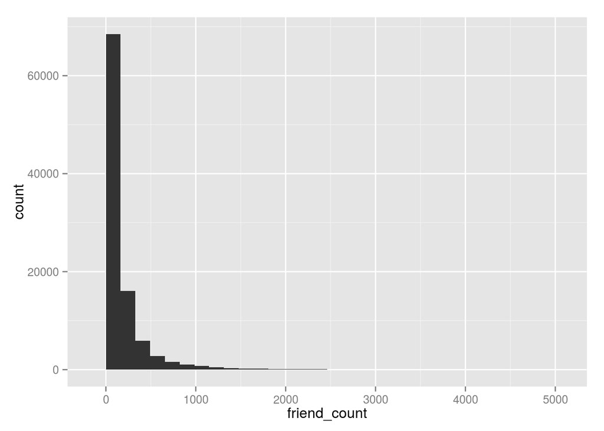

```r
qplot(x = friend_count, data = pf)
```

#### This has a long right tail. Let’s try the log of friend_count.

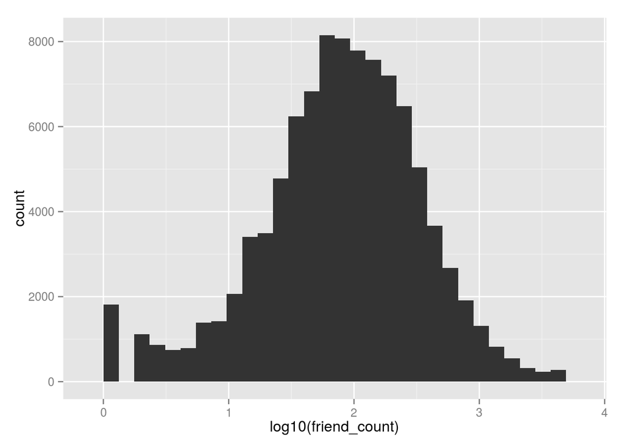

```r
qplot(x = log10(friend_count), data = pf)
```

```r
summary(log10(pf$friend_count))
```

```
##    Min. 1st Qu.  Median    Mean 3rd Qu.    Max.
##    -Inf       1       2    -Inf       2       4
```

#### So a mean of -Inf is weird, right?

#### Let’s add 1 to all of the friend counts to fix this.

```r
summary(log10(pf$friend_count + 1))
```

```
##    Min. 1st Qu.  Median    Mean 3rd Qu.    Max.
##   0.000   1.505   1.919   1.868   2.316   3.692
```

#### We could also see the square root of friend count.

```r
summary(sqrt(pf$friend_count))
```

```
##    Min. 1st Qu.  Median    Mean 3rd Qu.    Max.
##   0.000   5.568   9.055  11.090  14.350  70.160
```

#### Create 3 plots for friend count, log10 of friend count + 1 and sqrt of friend count

```r
library(gridExtra)
```

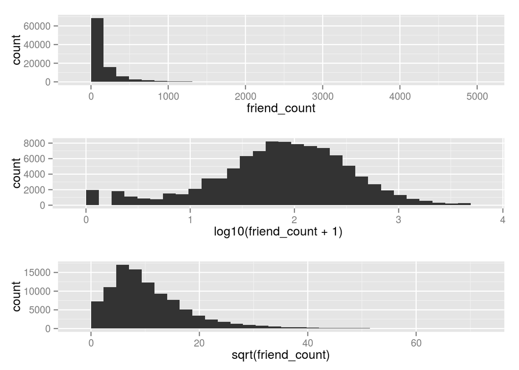

```r
p1 = qplot(x=friend_count, data=pf)
p2 = qplot(x=log10(friend_count+1), data=pf)
p3 = qplot(x=sqrt(friend_count), data=pf)

grid.arrange(p1,p2,p3, ncol=1)
```

#### The same plots using ggplot

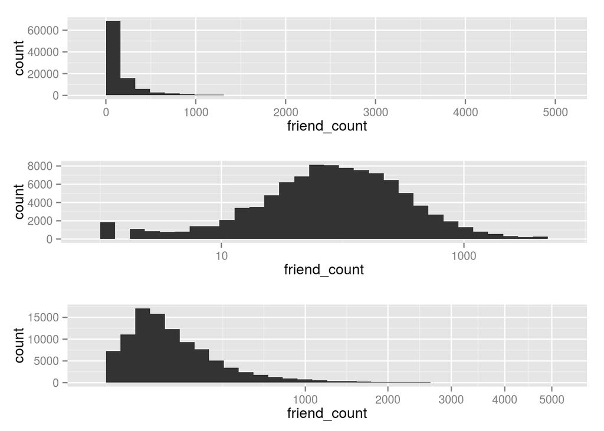

```r
p1 = ggplot(aes(x=friend_count), data=pf) +
  geom_histogram()
p2 = p1 + scale_x_log10()
p3 = p1 + scale_x_sqrt()
grid.arrange(p1, p2, p3, ncol=1)
```

### Add a Scaling Layer

This plots the same plot using qplot and ggplot. Notice that the x axis lable is different. In ggplot, you need to set the x label to accurately indicate the scale.

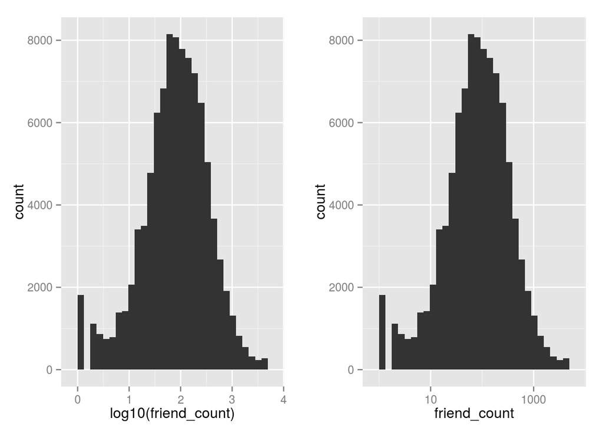

```r
logScale = qplot(x=log10(friend_count), data=pf)
countScale = ggplot(aes(x=friend_count), data=pf) +
  geom_histogram() +
  scale_x_log10()
grid.arrange(logScale, countScale, ncol=2)
```

### Frequency Polygon

We can plot likes by gender using a frequency polygons

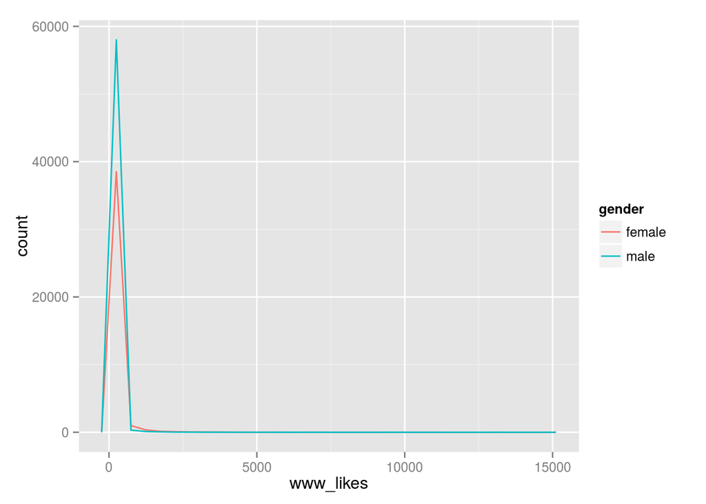

```r
qplot(x=www_likes, data=subset(pf,!is.na(gender)),
      geom='freqpoly', color=gender) +
  scale_x_continuous() #+
```

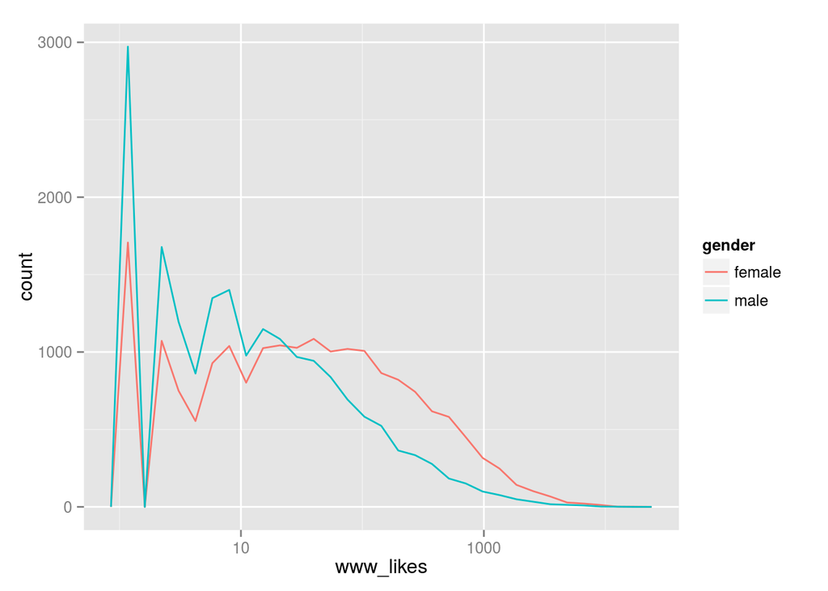

```r
  #scale_x_log10()

ggplot(aes(x = www_likes), data = subset(pf, !is.na(gender))) +
  geom_freqpoly(aes(color = gender)) +
  scale_x_log10()
```

```r
by(pf$www_likes, pf$gender, sum)
```

```
## pf$gender: female
## [1] 3507665
## --------------------------------------------------------
## pf$gender: male
## [1] 1430175
```

### We can also change the y axis to a proportion

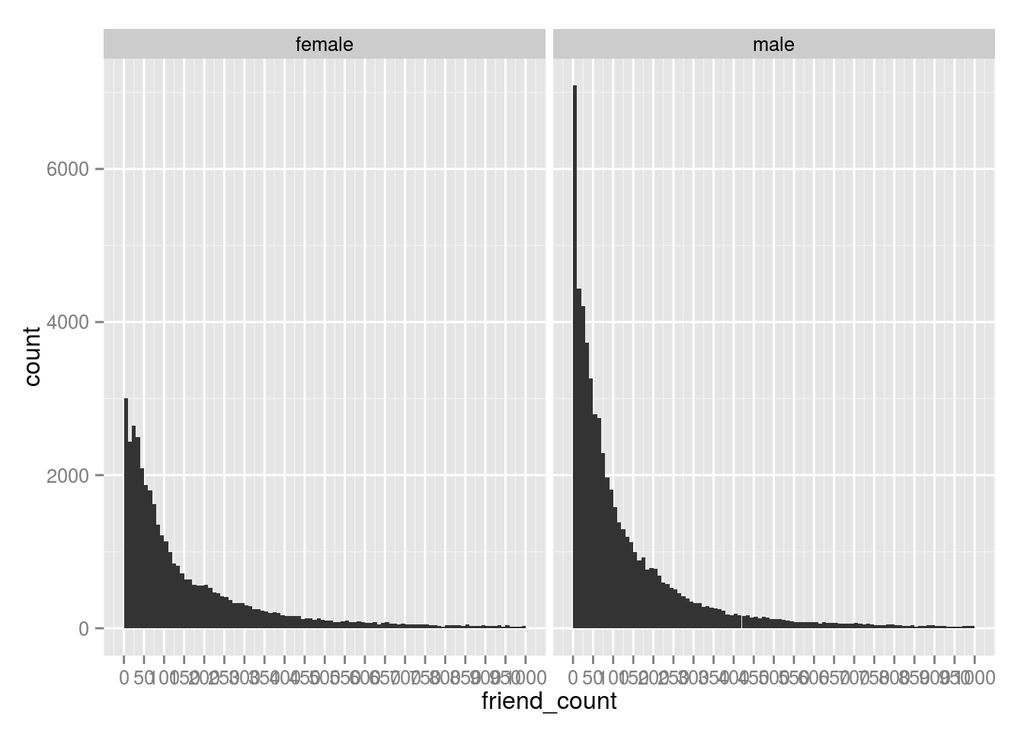

```r
qplot(x = friend_count, data = subset(pf, !is.na(gender)),
      binwidth = 10) +
  scale_x_continuous(lim = c(0, 1000), breaks = seq(0, 1000, 50)) +
  facet_wrap(~gender)
```

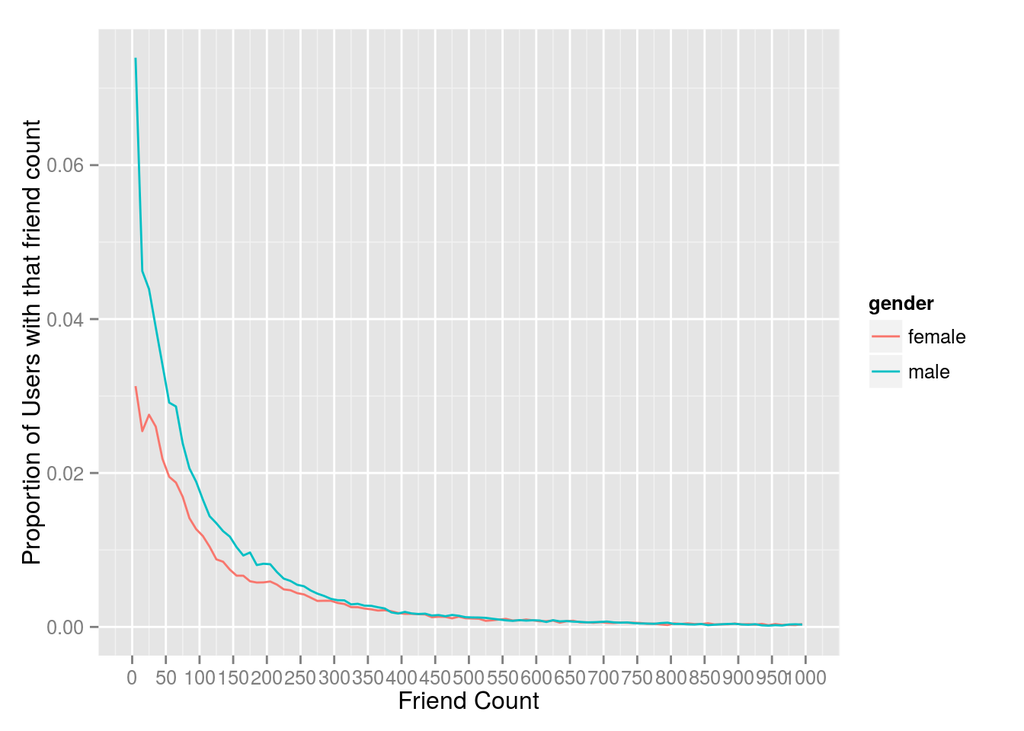

```r
qplot(x = friend_count, y = ..count../sum(..count..),
      data = subset(pf, !is.na(gender)),
      xlab = 'Friend Count',
      ylab = 'Proportion of Users with that friend count',
      binwidth = 10, geom = 'freqpoly', color = gender) +
  scale_x_continuous(lim = c(0, 1000), breaks = seq(0, 1000, 50))
```

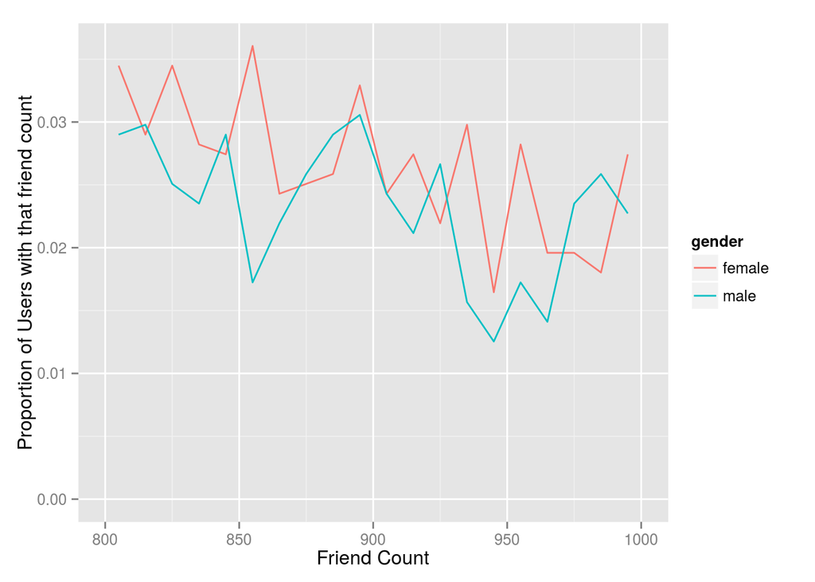

```r
qplot(x = friend_count, y = ..count../sum(..count..),
      data = subset(pf, !is.na(gender)),
      xlab = 'Friend Count',
      ylab = 'Proportion of Users with that friend count',
      binwidth = 10, geom = 'freqpoly', color = gender) +
  scale_x_continuous(lim = c(800, 1000), breaks = seq(0, 1000, 50))
```

```r
by(pf$www_likes, pf$gender, sum)
```

```
## pf$gender: female
## [1] 3507665
## --------------------------------------------------------
## pf$gender: male
## [1] 1430175
```

### Box Plots

Always pass the categorical variable for x and the continuous variable for y.

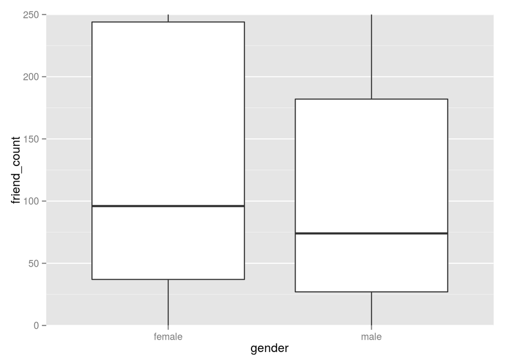

```r
qplot(x=gender, y=friend_count,
      data=subset(pf, !is.na(gender)),
      geom='boxplot') +
  coord_cartesian(ylim=c(0,250))
```

#### Use coord_cartesian to limit the y data visually, but keep the data points in the analysis. ***

### Box Plots, Quartiles, and Friendships

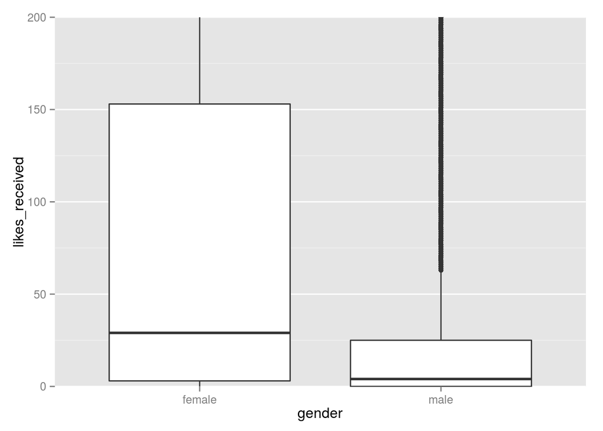

```r
qplot(x=gender, y=likes_received,
      data=subset(pf, !is.na(gender)),
      geom='boxplot') +
  coord_cartesian(ylim = c(0, 200))
```

```r
by(pf$friend_count, pf$gender, summary)
```

```
## pf$gender: female
##    Min. 1st Qu.  Median    Mean 3rd Qu.    Max.
##       0      37      96     242     244    4923
## --------------------------------------------------------
## pf$gender: male
##    Min. 1st Qu.  Median    Mean 3rd Qu.    Max.
##       0      27      74     165     182    4917
```

```r
by(pf$friendships_initiated, pf$gender, summary)
```

```
## pf$gender: female
##    Min. 1st Qu.  Median    Mean 3rd Qu.    Max.
##     0.0    19.0    49.0   113.9   124.8  3654.0
## --------------------------------------------------------
## pf$gender: male
##    Min. 1st Qu.  Median    Mean 3rd Qu.    Max.
##     0.0    15.0    44.0   103.1   111.0  4144.0
```

### Getting Logical

```r
summary(pf$mobile_likes)
```

```
##    Min. 1st Qu.  Median    Mean 3rd Qu.    Max.
##     0.0     0.0     4.0   106.1    46.0 25110.0
```

```r
summary(pf$mobile_likes > 0)
```

```
##    Mode   FALSE    TRUE    NA's
## logical   35056   63947       0
```

```r
mobile_check_in = NA
pf$mobile_check_in = ifelse(pf$mobile_likes > 0, 1, 0)
pf$mobile_check_in = factor(pf$mobile_check_in)
summary(pf$mobile_check_in)
```

```
##     0     1
## 35056 63947
```

```r
sum(pf$mobile_check_in == 1)/length(pf$mobile_check_in)
```

```
## [1] 0.6459097
```